# EDA

|  | Unnamed: 0 | ID объявления | Количество комнат | Тип | Метро | Адрес | Площадь, м2 | Дом | Парковка | Цена | ... | Окна | Санузел | Можно с детьми/животными | Дополнительно | Название ЖК | Серия дома | Высота потолков, м | Лифт | Мусоропровод | Ссылка на объявление |
| --- | --- | --- | --- | --- | --- | --- | --- | --- | --- | --- | --- | --- | --- | --- | --- | --- | --- | --- | --- | --- | --- |
| 23363 | 23363 | 215565511 | NaN | Квартира | м. Говорово (8 мин пешком) | Москва, Боровское шоссе, 2к7, ш. Боровское (3 ... | 35.0/16.4/8.0 | 10/14 | NaN | 42000.0 руб./ За месяц, Залог - 42000 руб., Ко... | ... | NaN | Совмещенный (1) | NaN | Мебель в комнатах, Мебель на кухне, Ванна, Сти... | Мещерский лес | NaN | NaN | Пасс (1), Груз (1) | NaN | https://www.cian.ru/rent/flat/215565511 |
| 23364 | 23364 | 274654844 | 1 | Квартира | м. Солнцево (7 мин пешком) | Москва, Производственная улица, 8к1, ш. Боровс... | 38.7/16.5/11.0 | 5/18, Монолитный | NaN | 45000.0 руб./ За месяц, Залог - 45000 руб., Ко... | ... | Во двор | Совмещенный (1) | NaN | Мебель в комнатах, Мебель на кухне, Ванна, Сти... | Лучи | NaN | NaN | Пасс (1), Груз (1) | NaN | https://www.cian.ru/rent/flat/274654844 |
| 23365 | 23365 | 268679909 | 2, Оба варианта | Квартира | м. Солнцево (6 мин пешком) | Москва, Боровский проезд, 11 | 43.1 | 5/5, Кирпичный | NaN | 50000.0 руб./ За месяц, Залог - 50000 руб., Ко... | ... | На улицу и двор | Совмещенный (1) | Можно с детьми | Мебель на кухне, Душевая кабина, Стиральная ма... | NaN | NaN | NaN | NaN | NaN | https://www.cian.ru/rent/flat/268679909 |
| 23366 | 23366 | 274807525 | 2 | Квартира | м. Солнцево (11 мин пешком) | Москва, улица Богданова, 6к1, ш. Боровское (3 ... | 52.5/10.0 | 8/23, Монолитный | наземная | 55000.0 руб./ За месяц, Залог - 50000 руб., Ко... | ... | Во двор | Совмещенный (1), Раздельный (1) | NaN | Мебель в комнатах, Мебель на кухне, Ванна, Сти... | NaN | NaN | 2.65 | Пасс (3) | Да | https://www.cian.ru/rent/flat/274807525 |
| 23367 | 23367 | 274672243 | 2, Оба варианта | Квартира | м. Говорово (10 мин пешком) | Москва, улица Богданова, 2к1, ш. Боровское (3 ... | 90.0/48.2/15.5 | 6/23, Панельный | NaN | 57000.0 руб./ За месяц, Залог - 60000 руб., Ко... | ... | Во двор | Раздельный (1) | Можно с детьми, Можно с животными | Мебель в комнатах, Мебель на кухне, Ванна, Сти... | NaN | NaN | NaN | Пасс (3) | Да | https://www.cian.ru/rent/flat/274672243 |

5 rows × 25 columns

|  | Unnamed: 0 | ID объявления | Количество комнат | Тип | Метро | Адрес | Площадь, м2 | Дом | Парковка | Цена | ... | Окна | Санузел | Можно с детьми/животными | Дополнительно | Название ЖК | Серия дома | Высота потолков, м | Лифт | Мусоропровод | Ссылка на объявление |
| --- | --- | --- | --- | --- | --- | --- | --- | --- | --- | --- | --- | --- | --- | --- | --- | --- | --- | --- | --- | --- | --- |
| 22328 | 22328 | 260506197 | 1 | Квартира | м. Бухарестская (1 мин пешком) | Санкт-Петербург, улица Салова, 61 | 34.5 | 7/18, Монолитный | наземная | 55000.0 руб./ За месяц, Залог - 55000 руб., Ср... | ... | NaN | NaN | Можно с детьми, Можно с животными | Мебель в комнатах, Мебель на кухне, Ванна, Душ... | Доходные апартаменты VALO, 2019 | NaN | 2.50 | Пасс (1), Груз (1) | NaN | https://www.cian.ru/rent/flat/260506197 |
| 17402 | 17402 | 271771237 | 2, Оба варианта | Квартира | м. Царицыно (26 мин пешком) | Москва, 6-я Радиальная улица, 5к1 | 70.0/40.0/15.0 | 3/15, Монолитный | NaN | 50000.0 руб./ За месяц, Залог - 55000 руб., Ко... | ... | На улицу и двор | Раздельный (2) | Можно с детьми | Мебель на кухне, Ванна | Царицыно, 2013 | NaN | NaN | Пасс (2) | Да | https://www.cian.ru/rent/flat/271771237 |
| 9927 | 9927 | 271438742 | 1 | Квартира | м. Крестовский остров (18 мин пешком) | Санкт-Петербург, Петровский проспект, 24к1 | 40.0/15.0/17.0 | 7/9, Монолитно-кирпичный | подземная | 65000.0 руб./ За месяц, Сумма коммунальных пла... | ... | Во двор | Совмещенный (1) | NaN | Мебель в комнатах, Мебель на кухне, Стиральная... | Петровский квартал на воде | NaN | NaN | Пасс (1) | NaN | https://www.cian.ru/rent/flat/271438742 |
| 14229 | 14229 | 273011737 | 3 | Квартира | м. Фрунзенская (6 мин пешком) | Москва, улица Усачева, 11Е | 100.0/7.0 | 4/13, Монолитный | подземная | 400000.0 руб./ За месяц, Залог - 400000 руб., ... | ... | Во двор | Совмещенный (2) | NaN | Мебель в комнатах, Мебель на кухне, Ванна, Душ... | Садовые кварталы, 2019 | NaN | NaN | NaN | NaN | https://www.cian.ru/rent/flat/273011737 |
| 5135 | 5135 | 273740725 | 4, Оба варианта | Квартира | м. Юго-Восточная (3 мин пешком) | Москва, Ташкентский переулок, 1 | 65.0/46.0/6.0 | 9/9, Панельный | наземная | 50000.0 руб./ За месяц, Залог - 50000 руб., Ко... | ... | На улицу и двор | Раздельный (1) | Можно с детьми | Мебель в комнатах, Мебель на кухне, Ванна, Сти... | NaN | П-49Д | 2.64 | Пасс (1) | Да | https://www.cian.ru/rent/flat/273740725 |

5 rows × 25 columns

|  | Unnamed: 0 | ID объявления | Количество комнат | Тип | Метро | Адрес | Площадь, м2 | Дом | Парковка | Цена | ... | Окна | Санузел | Можно с детьми/животными | Дополнительно | Название ЖК | Серия дома | Высота потолков, м | Лифт | Мусоропровод | Ссылка на объявление |
| --- | --- | --- | --- | --- | --- | --- | --- | --- | --- | --- | --- | --- | --- | --- | --- | --- | --- | --- | --- | --- | --- |
| 0 | 0 | 271271157 | 4 | Квартира | м. Смоленская (9 мин пешком) | Москва, улица Новый Арбат, 27 | 200.0/20.0 | 5/16, Монолитный | подземная | 500000.0 руб./ За месяц, Залог - 500000 руб., ... | ... | NaN | NaN | Можно с детьми, Можно с животными | Мебель в комнатах, Мебель на кухне, Ванна, Душ... | Новый Арбат, 2010 | NaN | 3.0 | Пасс (4), Груз (1) | Да | https://www.cian.ru/rent/flat/271271157 |
| 1 | 1 | 271634126 | 4 | Квартира | м. Смоленская (8 мин пешком) | Москва, улица Новый Арбат, 27 | 198.0/95.0/18.0 | 5/16, Монолитно-кирпичный | подземная | 500000.0 руб./ За месяц, Залог - 500000 руб., ... | ... | На улицу и двор | Совмещенный (2), Раздельный (1) | Можно с детьми | Мебель в комнатах, Мебель на кухне, Ванна, Душ... | Новый Арбат | NaN | 3.5 | Пасс (1), Груз (1) | Нет | https://www.cian.ru/rent/flat/271634126 |
| 2 | 2 | 271173086 | 4, Оба варианта | Квартира | м. Смоленская (7 мин пешком) | Москва, улица Новый Арбат, 27 | 200.0/116.0/4.0 | 5/16 | подземная | 500000.0 руб./ За месяц, Залог - 500000 руб., ... | ... | На улицу и двор | Совмещенный (3) | Можно с детьми | Мебель в комнатах, Мебель на кухне, Ванна, Душ... | Новый Арбат | NaN | 3.2 | Пасс (1) | NaN | https://www.cian.ru/rent/flat/271173086 |
| 3 | 3 | 272197456 | 4, Оба варианта | Квартира | м. Смоленская (3 мин пешком) | Москва, переулок Плотников, 21С1 | 170.0/95.0/17.0 | 5/6 | подземная | 400000.0 руб./ За месяц, Залог - 400000 руб., ... | ... | На улицу и двор | Совмещенный (3) | Можно с животными | Мебель в комнатах, Мебель на кухне, Ванна, Душ... | NaN | NaN | 3.2 | Пасс (1) | NaN | https://www.cian.ru/rent/flat/272197456 |
| 4 | 4 | 273614615 | 2 | Квартира | м. Арбатская (7 мин пешком) | Москва, улица Новый Арбат, 15 | 58.0/38.0/5.0 | 12/26, Панельный | NaN | 225000.0 руб./ За месяц, Залог - 225000 руб., ... | ... | На улицу и двор | Совмещенный (2) | NaN | Мебель в комнатах, Мебель на кухне, Ванна, Душ... | The Book | NaN | 3.9 | Пасс (1), Груз (1) | Да | https://www.cian.ru/rent/flat/273614615 |

5 rows × 25 columns

```
<class 'pandas.core.frame.DataFrame'>
RangeIndex: 23368 entries, 0 to 23367
Data columns (total 25 columns):
 #   Column                    Non-Null Count  Dtype
---  ------                    --------------  -----
 0   Unnamed: 0                23368 non-null  int64
 1   ID  объявления            23368 non-null  int64
 2   Количество комнат         22327 non-null  object
 3   Тип                       23368 non-null  object
 4   Метро                     22053 non-null  object
 5   Адрес                     23368 non-null  object
 6   Площадь, м2               23368 non-null  object
 7   Дом                       23368 non-null  object
 8   Парковка                  9951 non-null   object
 9   Цена                      23368 non-null  object
```

[output cut: 17 more lines]

Из исследования типов данных следует, что основной тип данных строки. Стоит привести количество комнат, цену, площадь к числовому значению. Рассмотреть необходимость проверки наличия лифта, парковки, мусоропровода и приведение его к занчениям true или false для модели.

```
Количество строк в таблице = 23368, количество столбцов (признаков) = 25
```

Ниже исследуем числовые значения

```
count    11206.00000
mean         2.98345
std          7.61472
min          1.20000
25%          2.64000
50%          2.64000
75%          2.80000
max        320.00000
Name: Высота потолков, м, dtype: float64
```

```
array([  3.  ,   3.5 ,   3.2 ,   3.9 ,    nan, 310.  ,   3.3 ,   4.  ,
         3.15,   4.15,   3.8 ,   3.35,   4.05,   3.6 ,   3.1 ,   4.2 ,
         2.8 ,   5.5 ,   2.5 ,   3.4 ,   2.4 ,   2.74,   2.6 ,   2.7 ,
         2.64,   2.75, 260.  ,   2.48,   2.52,   2.77,   2.78,   6.  ,
         2.95,   2.43,   2.9 ,   2.65,   2.54,   2.55,   2.72,   2.85,
         2.  ,   2.84,   2.58,   3.7 ,   4.6 ,   2.66,   2.68,   2.73,
        28.  ,   5.  ,   3.25,   4.5 , 264.  ,   2.57,  27.  ,   2.3 ,
         3.05,   3.07,   3.92,   2.86,   2.93,   2.94,   3.55,   2.67,
        12.8 ,   4.1 ,  26.  ,   2.76,   2.62,   2.87,   5.1 , 320.  ,
         4.7 , 265.  ,   2.56,   9.  ,   2.51,   2.63,   2.88,   2.81,
         3.08,   3.11,   5.8 ,   2.2 ,   2.45,   2.97,  25.  ,   2.1 ,
       280.  ,   3.56,   2.99,   3.41,   3.24,   3.21,   1.2 ,   3.02])
```

Ниже исследуем строковые значения

|  | Количество комнат | Тип | Метро | Адрес | Площадь, м2 | Дом | Парковка | Цена | Телефоны | Описание | ... | Балкон | Окна | Санузел | Можно с детьми/животными | Дополнительно | Название ЖК | Серия дома | Лифт | Мусоропровод | Ссылка на объявление |
| --- | --- | --- | --- | --- | --- | --- | --- | --- | --- | --- | --- | --- | --- | --- | --- | --- | --- | --- | --- | --- | --- |
| count | 22327 | 23368 | 22053 | 23368 | 23368 | 23368 | 9951 | 23368 | 23368 | 23368 | ... | 15390 | 16755 | 20696 | 17272 | 23011 | 5848 | 2163 | 17868 | 12846 | 23368 |
| unique | 24 | 1 | 5866 | 12850 | 11255 | 2565 | 5 | 3922 | 13172 | 23078 | ... | 18 | 3 | 20 | 3 | 528 | 1798 | 393 | 34 | 2 | 23368 |
| top | 1 | Квартира | м. Академическая (10 мин пешком) | Москва, Чапаевский переулок, 3 | 40.0/20.0/10.0 | 3/5, Кирпичный | наземная | 40000.0 руб./ За месяц, Залог - 40000 руб., Ко... | +79819217172 | 0 | ... | Балкон (1) | Во двор | Совмещенный (1) | Можно с детьми | Мебель в комнатах, Мебель на кухне, Ванна, Сти... | Символ, 2019 | индивидуальный проект | Пасс (1) | Да | https://www.cian.ru/rent/flat/271271157 |
| freq | 7917 | 23368 | 41 | 63 | 224 | 322 | 6043 | 1113 | 302 | 108 | ... | 7428 | 10870 | 10078 | 10134 | 2896 | 61 | 615 | 5911 | 10897 | 1 |

4 rows × 22 columns

Из данных ниже можно изучить количество пропущенных значений в каждой колонке

```
Unnamed: 0                      0
ID  объявления                  0
Количество комнат            1041
Тип                             0
Метро                        1315
Адрес                           0
Площадь, м2                     0
Дом                             0
Парковка                    13417
Цена                            0
Телефоны                        0
Описание                        0
Ремонт                       2755
Площадь комнат, м2           8910
Балкон                       7978
Окна                         6613
Санузел                      2672
Можно с детьми/животными     6096
Дополнительно                 357
Название ЖК                 17520
Серия дома                  21205
Высота потолков, м          12162
Лифт                         5500
Мусоропровод                10522
Ссылка на объявление            0
dtype: int64
```

### Анализ пропущенных значений

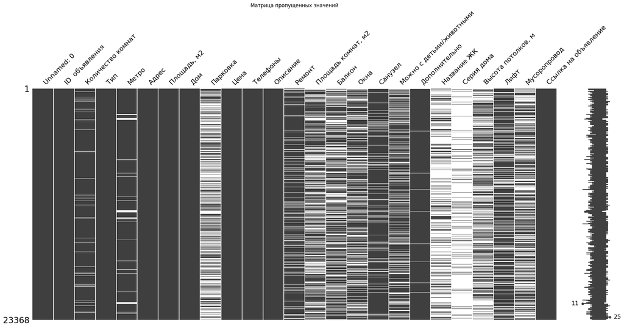

Посчитаем процент пустот в каждой из колонок

```
Unnamed: 0                   0.000000
ID  объявления               0.000000
Количество комнат            4.454810
Тип                          0.000000
Метро                        5.627354
Адрес                        0.000000
Площадь, м2                  0.000000
Дом                          0.000000
Парковка                    57.416125
Цена                         0.000000
Телефоны                     0.000000
Описание                     0.000000
Ремонт                      11.789627
Площадь комнат, м2          38.129065
Балкон                      34.140705
Окна                        28.299384
Санузел                     11.434440
Можно с детьми/животными    26.086957
Дополнительно                1.527730
Название ЖК                 74.974324
Серия дома                  90.743752
Высота потолков, м          52.045532
Лифт                        23.536460
Мусоропровод                45.027388
Ссылка на объявление         0.000000
dtype: float64
```

```
=== АНАЛИЗ ЦЕНЫ ===
Примеры значений в колонке 'Цена':
['500000.0 руб./ За месяц, Залог - 500000 руб., Коммунальные услуги включены, Срок аренды - Длительный, Предоплата 1 мес'
 '500000.0 руб./ За месяц, Залог - 500000 руб., Коммунальные услуги включены, Срок аренды - Длительный, Предоплата 1 мес'
 '500000.0 руб./ За месяц, Залог - 500000 руб., Срок аренды - Длительный, Предоплата 1 мес']
```

```
=== АНАЛИЗ ЦЕНЫ ===
Примеры значений в колонке 'Цена':
['500000.0 руб./ За месяц, Залог - 500000 руб., Коммунальные услуги включены, Срок аренды - Длительный, Предоплата 1 мес'
 '500000.0 руб./ За месяц, Залог - 500000 руб., Коммунальные услуги включены, Срок аренды - Длительный, Предоплата 1 мес'
 '500000.0 руб./ За месяц, Залог - 500000 руб., Срок аренды - Длительный, Предоплата 1 мес']
Способ 1 сработал!

Удалось извлечь цены: 23368 из 23368

=== СТАТИСТИКА ПО ЦЕНАМ ===
Минимальная цена: 5000 руб.
Максимальная цена: 3000000 руб.
Средняя цена: 82894 руб.
Медианная цена (типичная): 49500 руб.
```

```
=== СТАТИСТИКА ПО ЦЕНАМ ===
Минимальная цена: 5000 руб.
Максимальная цена: 3000000 руб.
Средняя цена: 82894 руб.
Медианная цена (типичная): 49500 руб.
```

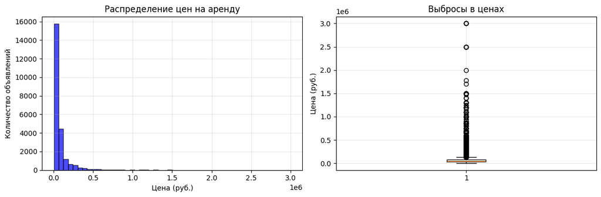

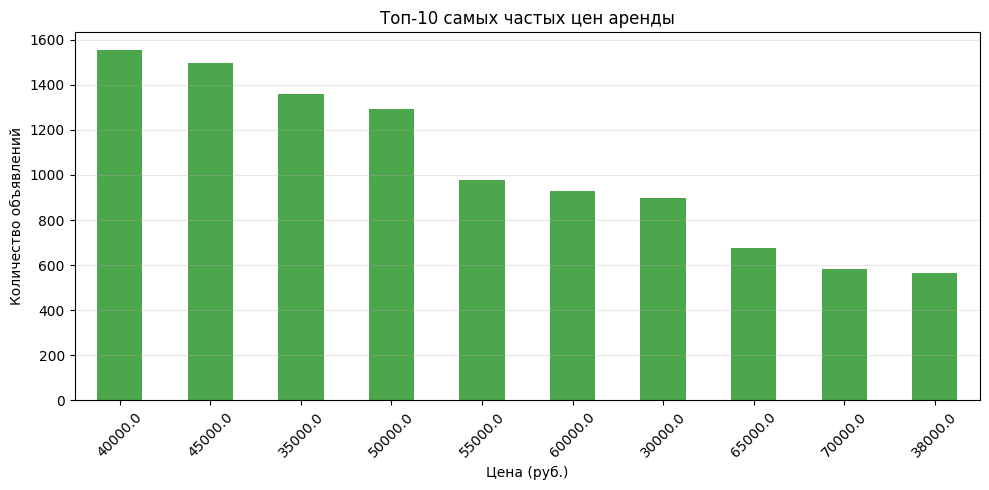

```
=== ГРАФИК: ПРОПУСКИ В ДАННЫХ ===
```

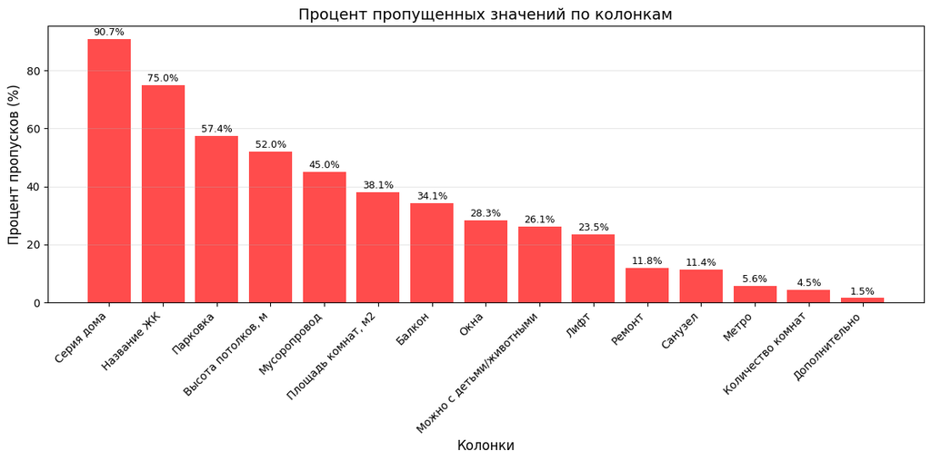

```
=== СТАТИСТИКА ПО ПРОПУСКАМ ===
Топ-5 колонок с наибольшими пропусками:
Серия дома: 90.7% пропусков
Название ЖК: 75.0% пропусков
Парковка: 57.4% пропусков
Высота потолков, м: 52.0% пропусков
Мусоропровод: 45.0% пропусков
```

### 1. ОСНОВНЫЕ ПРОБЛЕМЫ ДАННЫХ:

1. **Формат данных**: Цены и площади хранятся в текстовом формате с дополнительной информацией
2. **Пропуски**: Некоторые колонки имеют критическое количество пропусков:
   - Серия дома: ~91% пропусков
   - Название ЖК: ~75% пропусков
   - Парковка: ~57% пропусков
3. **Типы данных**: Большинство колонок имеют тип object (строка)

### 3. РЕКОМЕНДАЦИИ ДЛЯ РЕЛИЗА 2.0:

1. **Преобразовать цены**: Извлечь числовые значения из колонки "Цена"
2. **Обработать пропуски**:
   - Удалить колонки с >80% пропусков (Серия дома)
   - Заполнить или удалить колонки с 50-80% пропусков
   - Удалить колонку с телефонными номерами, т.к. данные не информативны для анализа
3. **Преобразовать другие колонки**:
   - "Площадь, м2" → числовое значение
   - "Количество комнат" → числовое значение
   - "Лифт", "Мусоропровод" → бинарные признаки (0/1)